# Extending Categorical Data Analysis

Michael Friendly

2025-12-18

```r
library(dplyr)
library(vcdExtra)
```

Here are some notes on some {vcd} and {vcdExtra} functions that could be made more usable, better documented or illustrated in examples.

They are prompted by the fact that I’m teaching my [Categorical Data Analysis course](https://friendly.github.io/6135/) again this year, but also from the view that statistical and graphic methods for categorical data have lagged far behind recent developments for traditional quantitative data. This might be a good time to look these over and try to make them more coherent and useful.

## Task View

Hey, what about a CRAN **Task View for Categorical Data Analysis**?

Here’s the start of such a list:

- {vcd}, {vcdExtra}, {gnm}, {pscl}, {MASS}, {nestedLogit} : functions for standard loglinear, glm models and extensions
- {VGAM} …

What other packages should be added?

A more detailed look at this possibility is included in the document [CRAN Task View: Categorical Data Analysis](https://github.com/friendly/vcdExtra/blob/master/issues/CDA-Task-View.md)

## tidyCat

> Frequency tables need some Tidy Love ❤️

Tidy methods for quantitative data & models have advanced considerably, but there hasn’t been much development of similar ideas for “categorical data”, by which I mean data that is often compactly represented as $n$-way frequency tables, cross classified by one or more discrete factors.

The vignette [tidyCat: Tidy Methods For Categorical Data Analysis](https://friendly.github.io/vcdExtra/articles/tidyCats.html) gives some initial thoughts on this topic.

## vcd documentation

I recently did an overhaul of {vcdExtra} to:

- Convert `.Rd` documentation to `roxygen` format. That was painful, because the {rd2roxygen} package made a mess of formatting, but the result is now much easier to maintain and extend. A benefit was that all datasets in the package are now documented in a single file, `R/data.R`, facilitating maintenance.
- Group statistical and graphic methods in broader categories for user ease in seeing what’s related. Most functions already use `@seealso`, but the documentation is much clearer using `@family` tags. In v. 0.8.7, I introduced the following in {vcdExtra} and this kind of classification would be very useful in {vcd}.

### `@family` tags

```r
# Mosaic plotting functions
@family mosaic plots
# Functions: mosaic.glm, mosaic.glmlist, mosaic3d, sieve.glm, assoc.glm

# Model list utilities
@family glmlist functions
# Functions: glmlist, print.glmlist, LRstats, Kway, mosaic.glmlist

# Statistical tests
@family association tests
# Functions: CMHtest, GKgamma, HLtest, zero.test

# Loglinear model utilities
@family loglinear models
# Functions: seq_loglm, loglmlist, conditional, joint, mutual, markov, saturated

# Data manipulation
@family data manipulation
# Functions: expand.dft, collapse.table, cutfac, datasets

# Model comparison
@family model comparison
# Functions: LRstats, Summarise, modFit, Kway
```

### `@concept` tags

- Provide a better way to use / understand the many datasets provided by the package. For this, I introduced `@concept` tags in the {heplots} package documentation to classify each dataset according to the methods applicable to them. I also applied this idea to the {HistData} package. The vignette [Data sets in the heplots package](https://friendly.github.io/heplots/articles/datasets.html) describes how this was done.
  - What are the “concepts” for vcd/vcdExtra datasets? I’ve done the initial steps on this: (a) A classification scheme based on categories of **Statistical Methods**, **Data Structures**, **Graphical Methods**, … For example:

```
### 1. **Statistical Methods** (primary analysis techniques)
- `loglinear-models` - Datasets for loglinear model analysis (~40+ datasets)
- `logistic-regression` - Binary/multinomial logistic models (Donner, ICU, Accident, Titanicp)
- `poisson-regression` - Poisson GLM applications (Accident, Cormorants, DaytonSurvey)
- `correspondence-analysis` - CA methods (AirCrash, Asbestos, HairEyePlace, HospVisits, Mental)
- `association-models` - Quasi-independence, RC models (Hauser79, Yamaguchi87, JobSat)
- `observer-agreement` - Agreement/reliability analysis (Mammograms)
- `count-models` - Zero-inflated, negative binomial (PhdPubs, CyclingDeaths, Depends)

### 2. **Data Structures**
- `two-way-table` - 2D contingency tables (Glass, JobSat, Mammograms, Mobility)
- `multi-way-table` - 3+ dimensional tables (Abortion, Bartlett, Caesar, Dyke, Heckman)
- `square-table` - Same categories for rows/columns (Glass, Hauser79, Mobility, Yamaguchi87)
- `stratified-table` - Layered analysis (Fungicide, Heart, HairEyePlace, Yamaguchi87)
- `ordered-factors` - Ordinal variables (Accident, Asbestos, JobSat, Mental, Toxaemia)
- `case-form-data` - Individual-level data frames (Donner, ICU, Titanicp)
```

2. Using this scheme, here are some Tentative tags for a few datasets

```
## Abortion
@concept loglinear-models
@concept multi-way-table
@concept mosaic-plot
@concept fourfold-plot
@concept binary-response
@concept survey-data

## Accident
@concept loglinear-models
@concept logistic-regression
@concept poisson-regression
@concept multi-way-table
@concept mosaic-plot
@concept ordered-factors
@concept demographics

## AirCrash
@concept correspondence-analysis
@concept two-way-table
@concept mosaic-plot
```

The complete scheme is described in these documents:

- [Dataset Classification Scheme for vcdExtra Package](https://github.com/friendly/vcdExtra/blob/master/issues/dataset_classification.md)
- [Dataset Concept Tags Proposal](https://github.com/friendly/vcdExtra/blob/master/issues/dataset_concepts.md)

Feedback on these categories and classifications would be very helpful before I implement this.

### `vcd` Datasets

There are 33 datasets in the {vcd} package. Would the same categories apply? (`one-way-table` would be new here)

```r
datasets("vcd", maxTitle=30)
```

```
##               Item      class             dim                          Title
## 1        Arthritis data.frame            84x5       Arthritis Treatment Data
## 2         Baseball data.frame          322x25                  Baseball Data
## 3   BrokenMarriage data.frame            20x4           Broken Marriage Data
## 4       Bundesliga data.frame         14018x7 Ergebnisse der Fussball-Bundes
## 5    Bundestag2005      table            16x5 Votes in German Bundestag Elec
## 6        Butterfly      table              24    Butterfly Species in Malaya
## 7       CoalMiners      table           2x2x9 Breathlessness and Wheeze in C
## 8    DanishWelfare data.frame           180x5      Danish Welfare Study Data
## 9       Employment      table           2x6x2              Employment Status
## 10      Federalist      table               7     'May' in Federalist Papers
## 11         Hitters data.frame           154x4                   Hitters Data
## 12      HorseKicks      table               5           Death by Horse Kicks
## 13        Hospital      table             3x3                  Hospital data
## 14 JobSatisfaction data.frame             8x4          Job Satisfaction Data
```

[output cut: 19 more lines]

Here are the one-way tables

```r
datasets("vcd", ndim=TRUE) |> dplyr::filter(ndim==1)
```

```
##         Item class ndim dim                       Title
## 1  Butterfly table    1  24 Butterfly Species in Malaya
## 2 Federalist table    1   7  'May' in Federalist Papers
## 3 HorseKicks table    1   5        Death by Horse Kicks
## 4     Saxony table    1  13          Families in Saxony
## 5 WeldonDice table    1  11          Weldon's Dice Data
## 6 WomenQueue table    1  11             Women in Queues
```

## Documentation examples

Some functions and datasets have extensive examples, some have only the bare minimum. It would be useful to revisit these in both {vcd} and {vcdExtra}

## Function improvements

Can some of the functions in these packages be generalized to be of (a) wider scope or (b) produce better output? I’ll list here a few things I’ve found

### `vcd::woolf_test()` for homogeneity of odds ratios

Only handles 3-way tables, 2 x 2 x k. Could extend this simply to the 2 x 2 x R x C case by taking all the R x C strata together, making this into a 2 x 2 x k table where k=R*C

e.g., for the `Fungicide` data, 2 x 2 x 2 x 2, `woolf_test()` gives an uninformative error.

```r
library(vcdExtra)
data(Fungicide, package = "vcdExtra")
# rearrange `group` for ease of interpretation, so odds ratio > 1 means worse outcome for Treated group
Fungicide <- Fungicide[2:1, , , ]
ftable(sex + strain ~ outcome + group, data=Fungicide)
```

```
##                 sex     M     F
##                 strain  1  2  1  2
## outcome group
## Tumor   Treated         4  4  2  1
##         Control         5 10  3  3
## NoTumor Treated        12 14 14 14
##         Control        74 80 84 79
```

```r
oddsratio(Fungicide) |>
  summary()
```

```
##
## z test of coefficients:
##
##     Estimate Std. Error z value Pr(>|z|)
## M:1  1.59601    0.73949  2.1583  0.03091 *
## F:1  1.38629    0.95743  1.4479  0.14763
## M:2  0.82668    0.65873  1.2550  0.20950
## F:2  0.63178    1.19055  0.5307  0.59566
## ---
## Signif. codes:  0 '***' 0.001 '**' 0.01 '*' 0.05 '.' 0.1 ' ' 1
```

```r
#' Woolf test only only handles 2 x 2 x k tables
try(woolf_test(Fungicide))
```

```
## Error in x[1, 1] : incorrect number of dimensions
```

#### Visualize the odds ratios

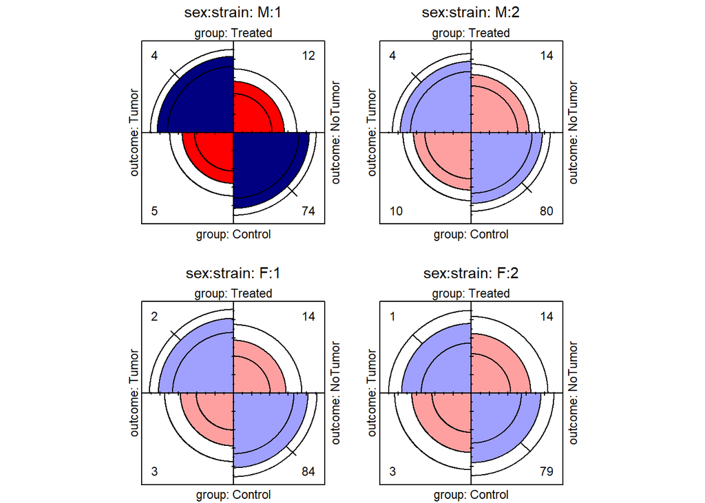

```r
fourfold(Fungicide, p_adjust_method = "none")
```

### Generalized `woolf_test()`

I generalized this in two ways:

#### Allow 3+ dimension

All dimensions after the first two are coalesced into a single 3rd dimension consisting of the combinations of all levels of these dimensions. We get a single overall test of differences in odds ratios for the collection of 2 x 2 tables.

```r
source(here::here("extra", "woolf_test_general.R"))

woolf_test_general(Fungicide)
```

```
##
##  Woolf-test on Homogeneity of Odds Ratios (no k-Way assoc.)
##
## data:  Fungicide
## X-squared = 0.85483, df = 3, p-value = 0.8363
```

**Source code**: woolf_test_general.R

#### Four-way case of 2 x 2 x R x C

A more interesting generalization for the four-way case of 2 x 2 x R x C is to treat the odds ratios as two-ways table of size R x C and calculate Woolf’s test over rows, columns and for the residual.

```r
source(here::here("extra", "woolf_test_2way.R"))

woolf_test_2way(Fungicide)
```

```
##
## Woolf Test with Two-Way Decomposition
## Data: Fungicide
##
## Overall homogeneity test:
##   X-squared = 0.8548, df = 3, p-value = 0.8363
##
## Decomposition:
##   Rows:      X-squared = 0.0086, df = 1, p-value = 0.9261
##   Columns:   X-squared = 0.8257, df = 1, p-value = 0.3635
##   Residual:  X-squared = 0.0205, df = 1, p-value = 0.8861
##
## Note: Overall = Rows + Columns + Residual
```

Source code: woolf_test_2way.R

#### Fully general version

This combines the ideas of these two enhancements, into a new version of `woolf_test()`. The case of a 4-way table is handled specially, with a new `decompose` argument, where `decompose == TRUE` does the row/col decomposition. It also has a new print method, which shows the OR variables, strata variables explicitly, and is fully documented in roxygen format.

```r
source(here::here("extra", "woolf_test_new.R"))

woolf_test(Fungicide)
```

```
##
## Woolf-test on Homogeneity of Odds Ratios (no 4-way association)
##
## Data:          Fungicide
## OR variables:  group, outcome
## Strata:        sex, strain
##
## X-squared = 0.8548, df = 3, p-value = 0.8363
```

```r
woolf_test(Fungicide, decompose = TRUE)
```

```
##
## Woolf-test on Homogeneity of Odds Ratios (no 4-way association)
##
## Data:          Fungicide
## OR variables:  group, outcome
## Strata:        sex, strain
##
## Overall homogeneity test:
##   X-squared = 0.8548, df = 3, p-value = 0.8363
##
## Decomposition:
##   Rows (sex):  X-squared = 0.0086, df = 1, p-value = 0.9261
##   Cols (strain):  X-squared = 0.8257, df = 1, p-value = 0.3635
##   Residual:       X-squared = 0.0205, df = 1, p-value = 0.8861
##
## Note: Overall = Rows + Columns + Residual
```

Source code: woolf_test_new.R

#### Recommendation

This version of `woolf_test()` should replace `vcd::woolf_test()`. I can do this in {vcdExtra} simply by masking the version in {vcd}, but it should better go into {vcd}.

I’m already overriding `print.Kappa()` which gives this message when I load the package:

```
Registered S3 method overwritten by 'vcdExtra':
  method      from
  print.Kappa vcd
```

## `vcd::assocstats()` print method

This is another case that could use work to make the results more comprehensible. At present, we get a list of the table LR, Pearson stats and coefficients for all the strata.